# Cluster Analysis

Roger Bukuru

2024-06-05

# Introduction

- Purpose: allocate item to groups
- Key characteristic: unsupervised
  - “Unsupervised” in the sense that we do not know which observations belong to groups
  - Can be used for feature extraction
    - This does not allocate observations to groups, but rather creates new varianles from the original x

What is a cluster ?

- A cluster is a set of items that are grouped together according to some criterion such as:
  - Proximity e.g k-means clustering, MDS
  - points with a lower dissimilarity are grouped together.A point (1, 0) has a lower Euclidean distance to a point (0, 1) than a point (5, 5), and so would be clustered with the (0, 1) point.
  - Probability
    - points allocated to probability distribution most likely to have generated them. Suppose point arose from either a N(0, 1) distribution or an N(5, 1) distribution. A point –1 would be allocated to cluster whose distribution matches the first.
  - Modality
    - Imagine 100 observations of one variable. If we plot the density of that variable and it has two peaks, then we could divide the data into two clusters.
  - Density
    - In a given dataset, 70% of observations lie between 0 and 1 and the remaining 30% lie between 5 and 6. The regions [0, 1] and [5, 6] are high-density regions, and points lying within those regions are clustered together.
- A cluster is generally thought of as a group of items (object, points) in which each item is “close” (in some appropriate sense) to a central item of a cluster and that members of different clusters are “far away” from each other.

There are numerous ways of clustering a data set of n independent measurements on each of r correlated variables - Clustering Observations: Mapping individual samples to a groups. The K groups is unknown and has to be determined from data - Clustering variables: Partition the $p$ variables into $K$ distinct groups, where the number K is unknown and has to be determied from the data. - Two-way clustering: Simultaneosuly cluster by observations and variables. Other names “block clustering”, “direct-clustering”, “biclustering”, or “co-clustering”.

## A few Clustering approaches

- Hierarchical
  - Agglomerative
    - Begin with each observation its own cluster, and merge clusters until one cluster
  - Divisive
    - Begin with one cluster, split until each observation is its own cluster.
- Partitioning
  - Distance-based: k-means, PAM, FANNY
  - Probability-based: clustering using Gaussian mixtures

### Hierarchical Clustering

- We tend to use a dendogram to determine the number of clusters
- Idea of Single Linkage, Complete Linkage and Average Linkage (influence how clusters are merged)
  - Cutting dendogram at a particular height leads to partitioning into a specified number of groups
  - Height of linkage refers to similarity of objects, the lower the height of merge, the more similar the objects
  - Mathematical algorithm described in notes.
- Linkages
  - Single Linkage: Minimum linage
    - The distance between two clusters is defined as the minimum distance between any single pair of points, one from each cluster
    - Can handle elongated or irregulary shaped clusters
    - Can lead to elongated clusters
  - Complete Linkage
    - The distance between two clusters is defined as the maximum distance between any single pair of points, one from each cluster.
    - Tendes to produce more compact clusters
    - Senstive to outliers, as the maximum distance can be heavily influenced by outlying points
  - Average Linkage
    - The distance between two clusters is defined as the average distance between all pairs of points, one from each other.
    - Provides a balance between single and complete linage
    - Less sensitive to outliers compared to complete linkage.

#### Example 1

```r
rm(list = ls())

library(cluster)
data = read.csv2("Ex12.3.4.csv", sep=",")
agglom_single = agnes(data, metric="euclidean", stand=FALSE, method="single", trace.lev = 5)
```

```
## C agnes(n=8, method = 2, ..): 7 merging steps
##  nmerge=0, j=2, d_min = D(6,8) = 1.41421;  -> (-6,-8); last=8; upd(n,b);
##  old D(A, j), D(B, j), j=1  = (6.7082,7.28011);  new D(A', 1) = 6.7082
##  old D(A, j), D(B, j), j=2  = (5.38516,6.08276);  new D(A', 2) = 5.38516
##  old D(A, j), D(B, j), j=3  = (5,5.38516);  new D(A', 3) = 5
##  old D(A, j), D(B, j), j=4  = (4.12311,5.38516);  new D(A', 4) = 4.12311
##  old D(A, j), D(B, j), j=5  = (2.23607,3.60555);  new D(A', 5) = 2.23607
##  old D(A, j), D(B, j), j=7  = (2.23607,2.23607);  new D(A', 7) = 2.23607
##  -->  size(A_new)= 2
##  nmerge=1, j=2, d_min = D(2,3) = 1.41421;  -> (-2,-3); last=3;
##  old D(A, j), D(B, j), j=1  = (1.41421,2);  new D(A', 1) = 1.41421
##  old D(A, j), D(B, j), j=4  = (3.16228,4);  new D(A', 4) = 3.16228
##  old D(A, j), D(B, j), j=5  = (4.24264,4.47214);  new D(A', 5) = 4.24264
##  old D(A, j), D(B, j), j=6  = (5.38516,5);  new D(A', 6) = 5
##  old D(A, j), D(B, j), j=7  = (4,3.16228);  new D(A', 7) = 3.16228
##  -->  size(A_new)= 2
##  nmerge=2, j=2, d_min = D(1,2) = 1.41421;  -> (-1,2); last=2;
##  old D(A, j), D(B, j), j=4  = (4.47214,3.16228);  new D(A', 4) = 3.16228
##  old D(A, j), D(B, j), j=5  = (5.65685,4.24264);  new D(A', 5) = 4.24264
##  old D(A, j), D(B, j), j=6  = (6.7082,5);  new D(A', 6) = 5
##  old D(A, j), D(B, j), j=7  = (5.09902,3.16228);  new D(A', 7) = 3.16228
##  -->  size(A_new)= 3
##  nmerge=3, j=4, d_min = D(4,5) = 2.00000;  -> (-4,-5); last=5;
##  old D(A, j), D(B, j), j=1  = (3.16228,4.24264);  new D(A', 1) = 3.16228
##  old D(A, j), D(B, j), j=6  = (4.12311,2.23607);  new D(A', 6) = 2.23607
##  old D(A, j), D(B, j), j=7  = (4.24264,3.16228);  new D(A', 7) = 3.16228
##  -->  size(A_new)= 2
##  nmerge=4, j=4, d_min = D(6,7) = 2.23607;  -> (1,-7); last=8;
##  old D(A, j), D(B, j), j=1  = (5,3.16228);  new D(A', 1) = 3.16228
##  old D(A, j), D(B, j), j=4  = (2.23607,3.16228);  new D(A', 4) = 2.23607
##  -->  size(A_new)= 3
##  nmerge=5, j=4, d_min = D(4,6) = 2.23607;  -> (4,5); last=6;
##  old D(A, j), D(B, j), j=1  = (3.16228,3.16228);  new D(A', 1) = 3.16228
##  -->  size(A_new)= 5
##  nmerge=6, j=4, d_min = D(1,4) = 3.16228;  -> (3,6); last=4;
##  -->  size(A_new)= 8
```

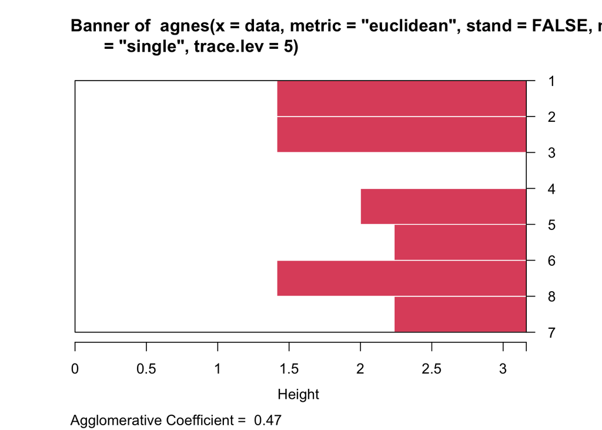

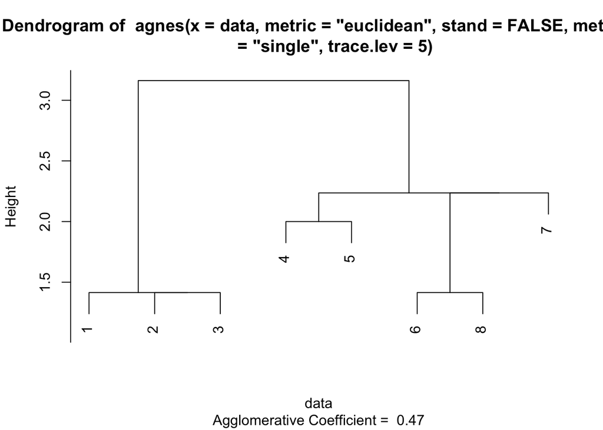

```r
plot(agglom_single)
```

```r
agglom_complete = agnes(data, metric="euclidean", stand=FALSE, method="complete", trace.lev = 5)
```

```
## C agnes(n=8, method = 3, ..): 7 merging steps
##  nmerge=0, j=2, d_min = D(6,8) = 1.41421;  -> (-6,-8); last=8; upd(n,b);
##  old D(A, j), D(B, j), j=1  = (6.7082,7.28011);  new D(A', 1) = 7.28011
##  old D(A, j), D(B, j), j=2  = (5.38516,6.08276);  new D(A', 2) = 6.08276
##  old D(A, j), D(B, j), j=3  = (5,5.38516);  new D(A', 3) = 5.38516
##  old D(A, j), D(B, j), j=4  = (4.12311,5.38516);  new D(A', 4) = 5.38516
##  old D(A, j), D(B, j), j=5  = (2.23607,3.60555);  new D(A', 5) = 3.60555
##  old D(A, j), D(B, j), j=7  = (2.23607,2.23607);  new D(A', 7) = 2.23607
##  -->  size(A_new)= 2
##  nmerge=1, j=2, d_min = D(2,3) = 1.41421;  -> (-2,-3); last=3;
##  old D(A, j), D(B, j), j=1  = (1.41421,2);  new D(A', 1) = 2
##  old D(A, j), D(B, j), j=4  = (3.16228,4);  new D(A', 4) = 4
##  old D(A, j), D(B, j), j=5  = (4.24264,4.47214);  new D(A', 5) = 4.47214
##  old D(A, j), D(B, j), j=6  = (6.08276,5.38516);  new D(A', 6) = 6.08276
##  old D(A, j), D(B, j), j=7  = (4,3.16228);  new D(A', 7) = 4
##  -->  size(A_new)= 2
##  nmerge=2, j=2, d_min = D(4,5) = 2.00000;  -> (-4,-5); last=5;
##  old D(A, j), D(B, j), j=1  = (4.47214,5.65685);  new D(A', 1) = 5.65685
##  old D(A, j), D(B, j), j=2  = (4,4.47214);  new D(A', 2) = 4.47214
##  old D(A, j), D(B, j), j=6  = (5.38516,3.60555);  new D(A', 6) = 5.38516
##  old D(A, j), D(B, j), j=7  = (4.24264,3.16228);  new D(A', 7) = 4.24264
##  -->  size(A_new)= 2
##  nmerge=3, j=2, d_min = D(1,2) = 2.00000;  -> (-1,2); last=2;
##  old D(A, j), D(B, j), j=4  = (5.65685,4.47214);  new D(A', 4) = 5.65685
##  old D(A, j), D(B, j), j=6  = (7.28011,6.08276);  new D(A', 6) = 7.28011
##  old D(A, j), D(B, j), j=7  = (5.09902,4);  new D(A', 7) = 5.09902
##  -->  size(A_new)= 3
##  nmerge=4, j=4, d_min = D(6,7) = 2.23607;  -> (1,-7); last=8;
##  old D(A, j), D(B, j), j=1  = (7.28011,5.09902);  new D(A', 1) = 7.28011
##  old D(A, j), D(B, j), j=4  = (5.38516,4.24264);  new D(A', 4) = 5.38516
##  -->  size(A_new)= 3
##  nmerge=5, j=4, d_min = D(4,6) = 5.38516;  -> (3,5); last=6;
##  old D(A, j), D(B, j), j=1  = (5.65685,7.28011);  new D(A', 1) = 7.28011
##  -->  size(A_new)= 5
##  nmerge=6, j=4, d_min = D(1,4) = 7.28011;  -> (4,6); last=4;
##  -->  size(A_new)= 8
```

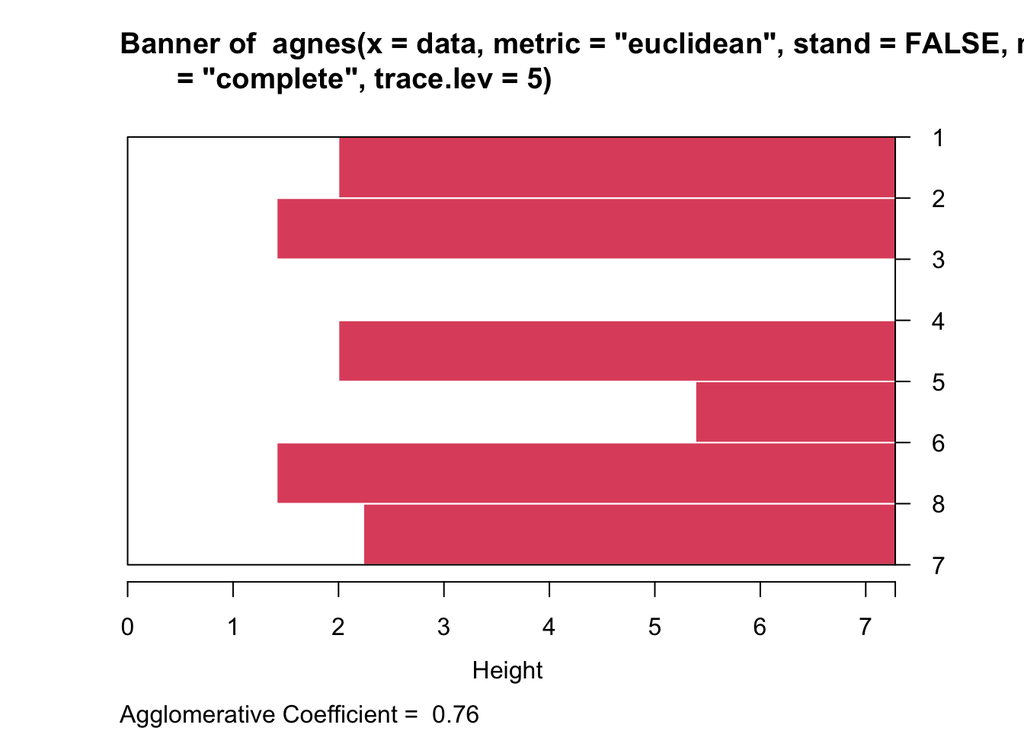

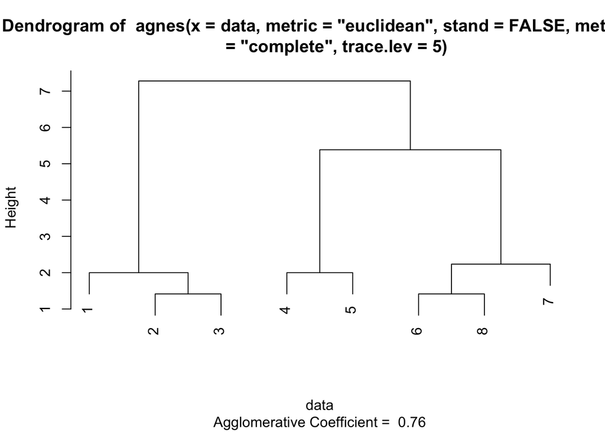

```r
plot(agglom_complete)
```

```r
agglom_average = agnes(data, metric="euclidean", stand=FALSE, method="average", trace.lev = 5)
```

```
## C agnes(n=8, method = 1, ..): 7 merging steps
##  nmerge=0, j=2, d_min = D(6,8) = 1.41421;  -> (-6,-8); last=8; upd(n,b);
##  old D(A, j), D(B, j), j=1  = (6.7082,7.28011);  new D(A', 1) = 6.99416
##  old D(A, j), D(B, j), j=2  = (5.38516,6.08276);  new D(A', 2) = 5.73396
##  old D(A, j), D(B, j), j=3  = (5,5.38516);  new D(A', 3) = 5.19258
##  old D(A, j), D(B, j), j=4  = (4.12311,5.38516);  new D(A', 4) = 4.75414
##  old D(A, j), D(B, j), j=5  = (2.23607,3.60555);  new D(A', 5) = 2.92081
##  old D(A, j), D(B, j), j=7  = (2.23607,2.23607);  new D(A', 7) = 2.23607
##  -->  size(A_new)= 2
##  nmerge=1, j=2, d_min = D(2,3) = 1.41421;  -> (-2,-3); last=3;
##  old D(A, j), D(B, j), j=1  = (1.41421,2);  new D(A', 1) = 1.70711
##  old D(A, j), D(B, j), j=4  = (3.16228,4);  new D(A', 4) = 3.58114
##  old D(A, j), D(B, j), j=5  = (4.24264,4.47214);  new D(A', 5) = 4.35739
##  old D(A, j), D(B, j), j=6  = (5.73396,5.19258);  new D(A', 6) = 5.46327
##  old D(A, j), D(B, j), j=7  = (4,3.16228);  new D(A', 7) = 3.58114
##  -->  size(A_new)= 2
##  nmerge=2, j=2, d_min = D(1,2) = 1.70711;  -> (-1,2); last=2;
##  old D(A, j), D(B, j), j=4  = (4.47214,3.58114);  new D(A', 4) = 3.87814
##  old D(A, j), D(B, j), j=5  = (5.65685,4.35739);  new D(A', 5) = 4.79054
##  old D(A, j), D(B, j), j=6  = (6.99416,5.46327);  new D(A', 6) = 5.97357
##  old D(A, j), D(B, j), j=7  = (5.09902,3.58114);  new D(A', 7) = 4.0871
##  -->  size(A_new)= 3
##  nmerge=3, j=4, d_min = D(4,5) = 2.00000;  -> (-4,-5); last=5;
##  old D(A, j), D(B, j), j=1  = (3.87814,4.79054);  new D(A', 1) = 4.33434
##  old D(A, j), D(B, j), j=6  = (4.75414,2.92081);  new D(A', 6) = 3.83747
##  old D(A, j), D(B, j), j=7  = (4.24264,3.16228);  new D(A', 7) = 3.70246
##  -->  size(A_new)= 2
##  nmerge=4, j=4, d_min = D(6,7) = 2.23607;  -> (1,-7); last=8;
##  old D(A, j), D(B, j), j=1  = (5.97357,4.0871);  new D(A', 1) = 5.34474
##  old D(A, j), D(B, j), j=4  = (3.83747,3.70246);  new D(A', 4) = 3.79247
##  -->  size(A_new)= 3
##  nmerge=5, j=4, d_min = D(4,6) = 3.79247;  -> (4,5); last=6;
##  old D(A, j), D(B, j), j=1  = (4.33434,5.34474);  new D(A', 1) = 4.94058
##  -->  size(A_new)= 5
##  nmerge=6, j=4, d_min = D(1,4) = 4.94058;  -> (3,6); last=4;
##  -->  size(A_new)= 8
```

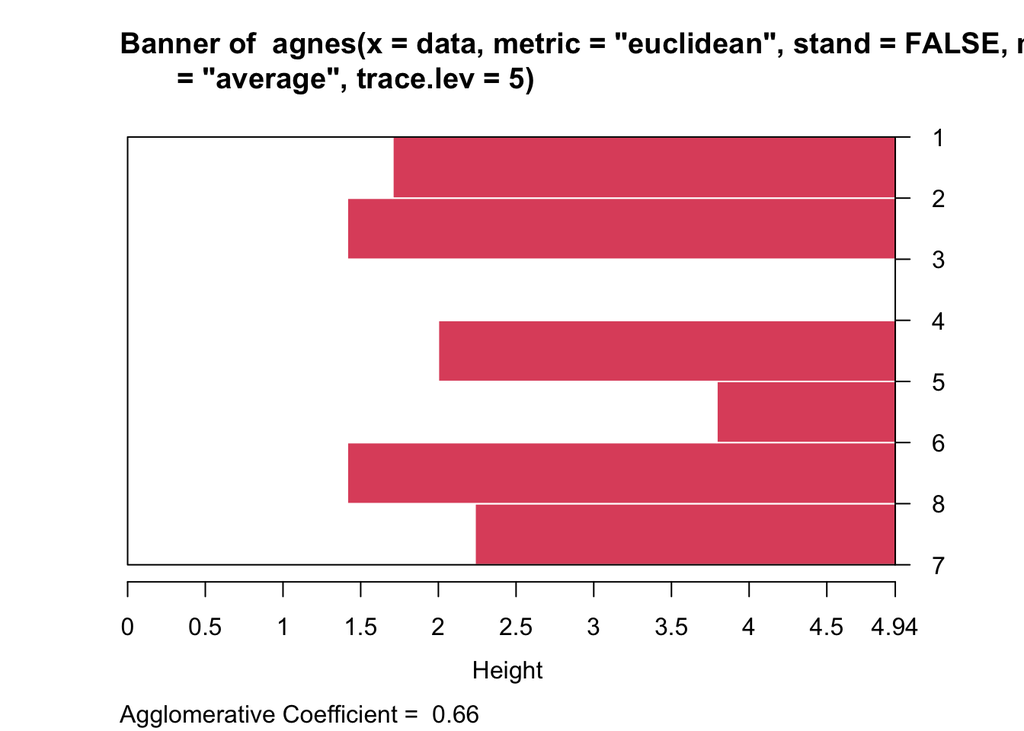

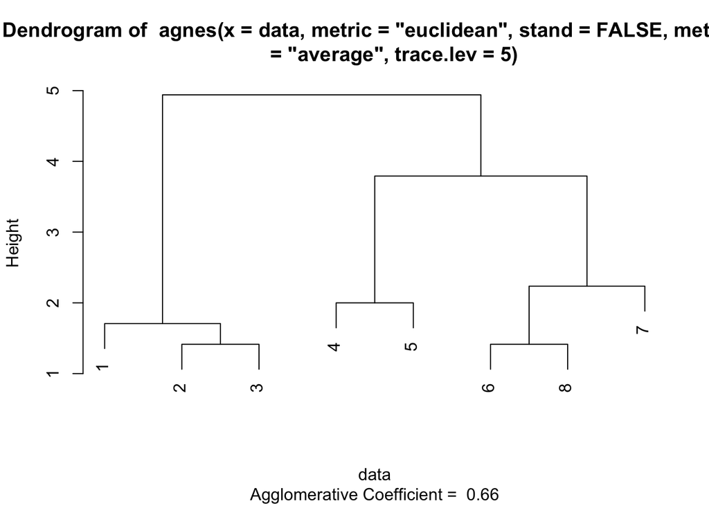

```r
plot(agglom_average)
```

```r
divisive_average = diana(data, metric="euclidean", stand=FALSE, trace.lev = 5)
```

```
## C diana(): ndist= 29, diameter = 7.28011
```

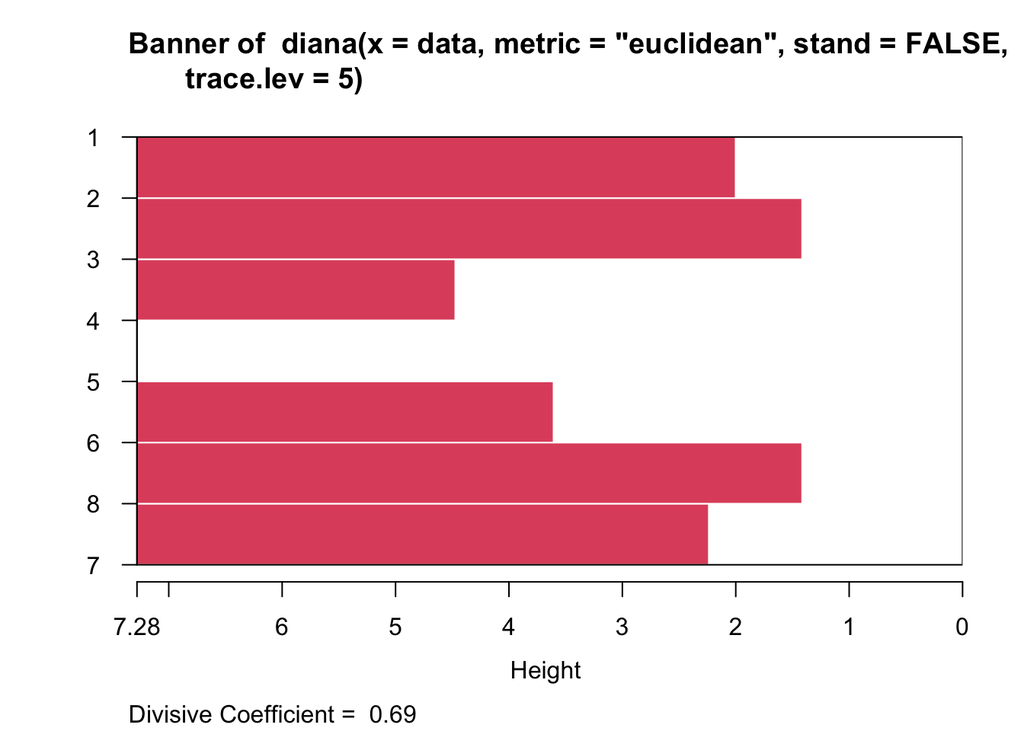

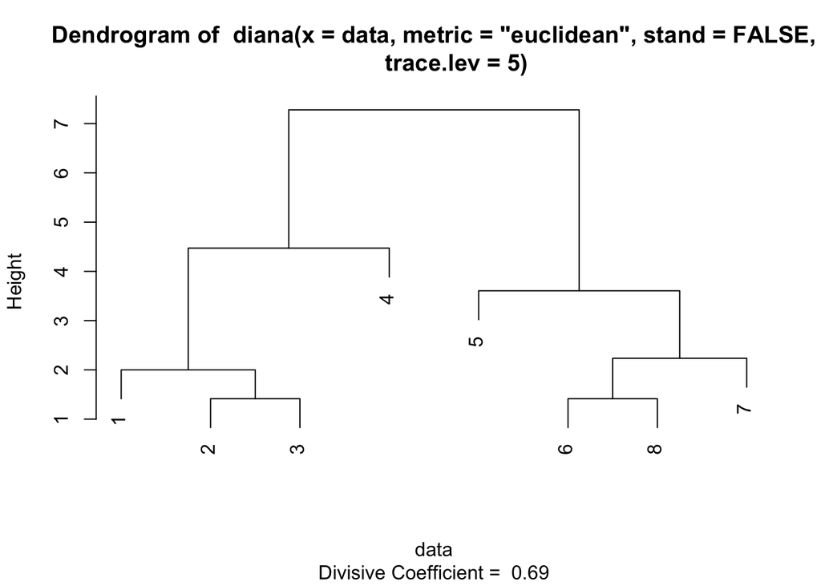

```r
plot(divisive_average)
```

- Agglomerative coefficient measures strength of clustering, through average of normalized lengths of dendrogram - Dimensionless between 0 and 1 - The nearer to one the better

**Analysis of clusters**

- Single linkage can start to show long stringy clusters as the inputs grow

The GAP statistic

- To decide on value of k(cluster size)
- We wish to choose the value of k that maximizes the gap statistic

# Nonhierarchical or Partitioning Methods

- Seek to split data into a predetermined number K groups such that the items within each cluster are similar to each other, whereas items from different clusters are dissimilar.
- Partitioning Methods
  - K-means (kmeans)
  - Partitioning around mediods (pam)
- Mode-searching (bump-hunting) methods
  - using parametric mixtures or nonparametric density estimates (Mclust)

## Combinatorial Algorithms

- Characterized by a many-to-one mapping or encoder $k=c(i)$ that assigns the ith observation to the k-th cluster
- $c(i)$ is determined by finding the one that will minimize a “loss” function
- A natural loss functions is what we refer to as the “within-cluster” distance $W(c)= T-B(c)$

```r
rm(list = ls())
primate = read.csv2("primate.scapulae.csv", sep=",")
#clusGap(primate, FUN = kmeans, K.max = 5)
```

## K-means clustering

1. Input items: data matrix
2. Do one of the following
- Form an initial random assignment of the items into K clusters and for cluster k, compute its current centroid $\bar{x}m k=1,2,...K$
- Pre-specify K cluster centroids $\bar{x}m k=1,2,...K$
3. Compute the squared euclidean distance of each item to its current cluster centroid
4. Reassign each item to its nearest cluster centroid so that ESS is reduced in magnitude. Update the cluster centroids after each assignment
5. Repeat steps 3 and 4 until no further reassignment of items takes place.

```r
rm(list = ls())

library(cluster)
data = read.csv2("Ex12.3.4.csv", sep = ",")
kmeans1 = kmeans(data, 4)
kmeans1
```

```
## K-means clustering with 4 clusters of sizes 2, 3, 1, 2
##
## Cluster means:
##         X1  X2
## 1 3.500000 9.5
## 2 1.333333 4.0
## 3 2.000000 8.0
## 4 5.000000 6.0
##
## Clustering vector:
## [1] 2 2 2 4 4 1 3 1
##
## Within cluster sum of squares by cluster:
## [1] 1.000000 2.666667 0.000000 2.000000
##  (between_SS / total_SS =  91.0 %)
##
## Available components:
##
## [1] "cluster"      "centers"      "totss"        "withinss"     "tot.withinss"
## [6] "betweenss"    "size"         "iter"         "ifault"
```

```r
fitted(kmeans1)
```

```
##         X1  X2
## 2 1.333333 4.0
## 2 1.333333 4.0
## 2 1.333333 4.0
## 4 5.000000 6.0
## 4 5.000000 6.0
## 1 3.500000 9.5
## 3 2.000000 8.0
## 1 3.500000 9.5
```

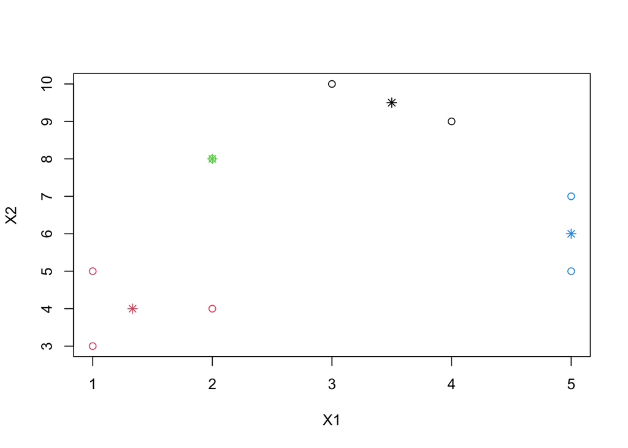

```r
plot(data, col=kmeans1$cluster)
points(kmeans1$centers, col=1:4, pch=8)
```

## K-mediod and partitioning-around medoids clustering

```r
rm(list = ls())

library(cluster)
data = read.csv2("Ex12.3.4.csv", sep = ",")
pam1 = pam(data, 4, trace.lev = 5)
```

```
## C pam(): computing 29 dissimilarities from  8 x 2  matrix: [Ok]
## pam()'s bswap(*, s=7.28011, pamonce=0): build 4 medoids:
##     new repr. 7
##     new repr. 2
##     new repr. 5
##     new repr. 8
##   after build: medoids are 2 5 7 8
##   and min.dist dysma[1:n] are
##    1.41      0   1.41      2      0   1.41      0      0
## end{bswap()}, end{cstat()}
```

```r
summary(pam1)
```

```
## Medoids:
##      ID X1 X2
## [1,]  2  2  4
## [2,]  5  5  7
## [3,]  8  3 10
## [4,]  7  2  8
## Clustering vector:
## [1] 1 1 1 2 2 3 4 3
## Objective function:
##     build      swap
## 0.7803301 0.7803301
##
## Numerical information per cluster:
##      size max_diss   av_diss diameter separation
## [1,]    3 1.414214 0.9428090 2.000000   3.162278
## [2,]    2 2.000000 1.0000000 2.000000   2.236068
## [3,]    2 1.414214 0.7071068 1.414214   2.236068
## [4,]    1 0.000000 0.0000000 0.000000   2.236068
##
## Isolated clusters:
##  L-clusters: character(0)
##  L*-clusters: [1] 1 2 3
##
## Silhouette plot information:
##   cluster neighbor sil_width
## 1       1        2 0.6629266
## 2       1        2 0.6180340
## 3       1        4 0.4601654
## 4       2        1 0.4842886
## 5       2        3 0.3152584
## 6       3        4 0.3675445
## 8       3        4 0.3675445
## 7       4        3 0.0000000
## Average silhouette width per cluster:
## [1] 0.5803753 0.3997735 0.3675445 0.0000000
## Average silhouette width of total data set:
## [1] 0.4094702
##
## 28 dissimilarities, summarized :
##    Min. 1st Qu.  Median    Mean 3rd Qu.    Max.
##   1.414   2.236   4.062   3.913   5.171   7.280
## Metric :  euclidean
## Number of objects : 8
##
## Available components:
##  [1] "medoids"    "id.med"     "clustering" "objective"  "isolation"
##  [6] "clusinfo"   "silinfo"    "diss"       "call"       "data"
```

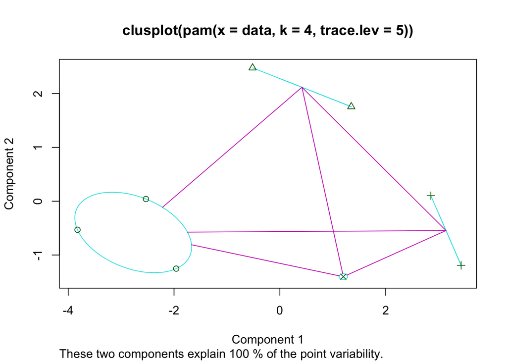

```r
clusplot(pam1)
```

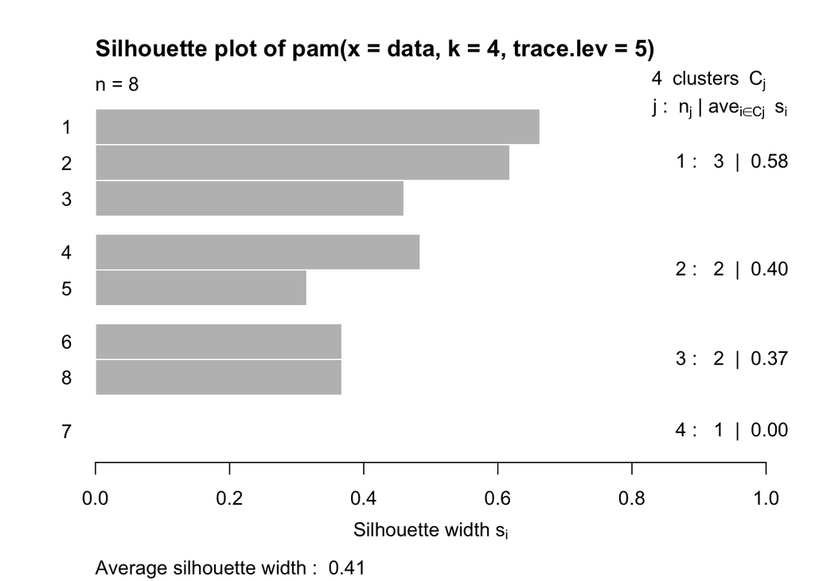

```r
plot(pam1)
```

- k-means is sensitive to outlier. As means are sensitive to outlier
- k-medoids: instead of taking the mean value of the object in a cluster as a reference point, medois can be used, which is the most centrally located object in a cluster

From the diagrams - The pink lines join medoids - Ellipses bound points in a cluster - Note that lines are “collapsed” ellipses when the clusters only have two observations - Silhouette Plot - A graphical display of the partitioning - The $ith$ silhouette value is $s_i(C_k)=s_{iK}=\frac{b_i-a_i}{max\{a_i,b_i\}}$ Where - $a_i=$ average dissimilarity of $i-th$ item from all members of same cluster, $c(i)$ - $b_j=$ minimum average dissimilarity of $i-th$ item to all members of clusters other than $c(i)$ - See slides for the rest of the details.

## Fuzzy Analysis (FANNY)

- Allows for ambiguity in the data since each object spread over various clusters with degree of belonging to a cluster quantified by a membership coefficient that ranges from 0 to 1
- Aims to minimize C = $\sum_{v=1}^{k} \frac{\sum_{i,j=1}^{n} u_{iv}^2 u_{jv}^2 d(i,j)}{2 \sum_{l=1}^{n} u_{lk}^2}$
  - Where $d(i,j) = \text{distance between objects } i \text{ and } j$
  - $u_{iv} = \text{unknown membership of object } i \text{ to cluster } v, \text{ subject to } u_{iv} \geq 0 \text{ and } \sum_{v} u_{iv} = 1$

```r
rm(list = ls())

library(cluster)
data = read.csv2("Ex12.3.4.csv", sep = ",")
fanny1 = fanny(data, 3)
summary(fanny1)
```

```
## Fuzzy Clustering object of class 'fanny' :
## m.ship.expon.        2
## objective     3.428394
## tolerance        1e-15
## iterations          90
## converged            1
## maxit              500
## n                    8
## Membership coefficients (in %, rounded):
##      [,1] [,2] [,3]
## [1,]   80   12    8
## [2,]   83   11    7
## [3,]   74   15   12
## [4,]   12   79    9
## [5,]   10   71   18
## [6,]    7   15   78
## [7,]   20   24   56
## [8,]    6   10   84
## Fuzzyness coefficients:
## dunn_coeff normalized
##  0.6135521  0.4203281
## Closest hard clustering:
## [1] 1 1 1 2 2 3 3 3
##
## Silhouette plot information:
##   cluster neighbor sil_width
## 1       1        2 0.6629266
## 2       1        2 0.6180340
## 3       1        2 0.5970068
## 4       2        1 0.4842886
## 5       2        3 0.3336219
## 8       3        2 0.5939943
## 6       3        2 0.4259818
## 7       3        2 0.3960587
## Average silhouette width per cluster:
## [1] 0.6259891 0.4089552 0.4720116
## Average silhouette width of total data set:
## [1] 0.5139891
##
## 28 dissimilarities, summarized :
##    Min. 1st Qu.  Median    Mean 3rd Qu.    Max.
##   1.414   2.236   4.062   3.913   5.171   7.280
## Metric :  euclidean
## Number of objects : 8
##
## Available components:
##  [1] "membership"  "coeff"       "memb.exp"    "clustering"  "k.crisp"
##  [6] "objective"   "convergence" "diss"        "call"        "silinfo"
## [11] "data"
```

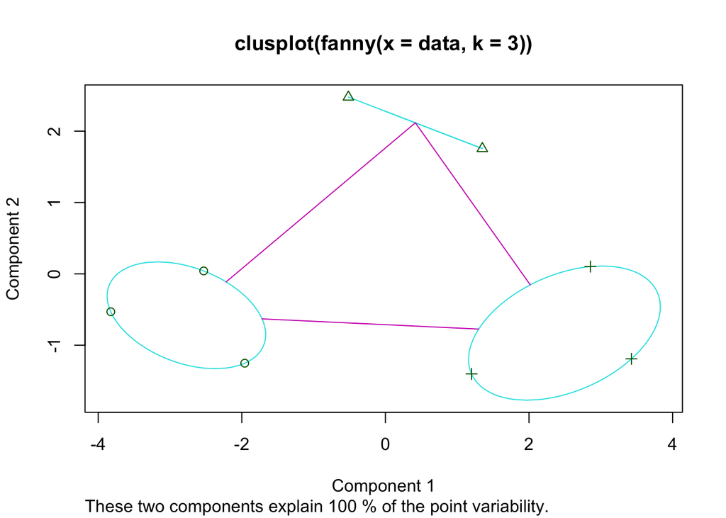

```r
clusplot(fanny1)
```

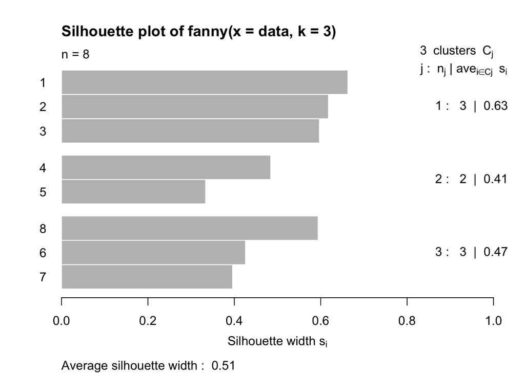

```r
plot(fanny1)
```

## Clustering Large Applications (CLARA)

- Based in k-medoid approach Carried out in 2 steps:
  1. a sample is drawn from the set of objects and clustered into k subsets using the k-medoid method, which also gives k representative objects
  2. each object not belonging to the sample is assigned to the nearest of the k representative objects. - A measure of the quality of this clustering is obtained by computing the average distance between each object of the data set and its representative object. - After 5 samples have been drawn and clustered, the one is selected for which the lowest average distance was obtained.

```r
rm(list = ls())
library(tidyverse)
library(dplyr)
library(ggplot2)

satimage = read_table("satimage.txt", col_names = TRUE)
colnames(satimage) <- gsub('"', '', colnames(satimage))
satimage$class <- gsub('"', '', satimage$class)

satimage = satimage %>%
  mutate(class = as.factor(class))

clara1 = clara(satimage, 6, trace = 2)
```

```
## C clara(): (nsam,nran,n) = (52,5,4435);
## - clara sample  1  finding 1st... new k{ran}:
## .. kall: FALSE, nsel[ntt=1] = 0
##  [ntt=52, nunfs=0]  -> dysta2();
##  clara -> s:= max{dys[1..1326]} = 320.383;
##  bswap2(), 1. BUILD: 40 21 10 6 26 20  after build: medoids are  6 10 20 21 26 40
##  --> sky = sum_j D_j= 2460.09
##   Last swap: new 3 <-> 6 old; decreasing diss. by 1
##  end{bswap2}: sky = 2444.56
## 1st proper sample obj= 53.4363
## - clara sample  2  if (kall && nunfs...):
## .. kall: T, nsel[ntt=6] = 496
##  [ntt=52, nunfs=0]  -> dysta2();
##  clara -> s:= max{dys[1..1326]} = 274.985;
##  bswap2(), 1. BUILD: 25 47 26 10 42 6  after build: medoids are  6 10 25 26 42 47
##  --> sky = sum_j D_j= 2375.74
##   Last swap: new 24 <-> 47 old; decreasing diss. by 1
##  end{bswap2}: sky = 2349.19
## new best obj= 50.5009
## - clara sample  3  if (kall && nunfs...):
## .. kall: T, nsel[ntt=6] = 565
##  [ntt=52, nunfs=0]  -> dysta2();
##  clara -> s:= max{dys[1..1326]} = 293.54;
##  bswap2(), 1. BUILD: 6 13 14 30 39 52  after build: medoids are  6 13 14 30 39 52
##  --> sky = sum_j D_j= 2241.87
##   Last swap: new 28 <-> 30 old; decreasing diss. by 1
##  end{bswap2}: sky = 2230.93
## new best obj= 50.2502
## - clara sample  4  if (kall && nunfs...):
## .. kall: T, nsel[ntt=6] = 276
##  [ntt=52, nunfs=0]  -> dysta2();
##  clara -> s:= max{dys[1..1326]} = 294.858;
##  bswap2(), 1. BUILD: 52 20 49 9 29 12  after build: medoids are  9 12 20 29 49 52
##  --> sky = sum_j D_j= 2439.36
##   Last swap: new 7 <-> 9 old; decreasing diss. by 0
##  end{bswap2}: sky = 2439.36
##  obj= 55.1352
## - clara sample  5  if (kall && nunfs...):
## .. kall: T, nsel[ntt=6] = 775
##  [ntt=52, nunfs=0]  -> dysta2();
##  clara -> s:= max{dys[1..1326]} = 329.39;
##  bswap2(), 1. BUILD: 44 1 7 30 52 29  after build: medoids are  1  7 29 30 44 52
##  --> sky = sum_j D_j= 2221.85
##   Last swap: new 3 <-> 1 old; decreasing diss. by 1
##  end{bswap2}: sky = 2191.09
##  obj= 50.8393
## C clara() -> best sample _found_ ; nbest[1:52] =
##  c(29,134,136,179,249,264,276,308,329,418,658,661,665,775,926,1501,1515,1560,1565,1605,
##   1888,1894,1950,2012,2013,2134,2236,2352,2357,2400,2407,2556,2589,2626,2648,2818,2828,2834,2877,3050,
##   3087,3280,3359,3566,3693,3735,3750,3762,3831,3966,4034,4124)
##  resul(),  black() and return() from C.
```

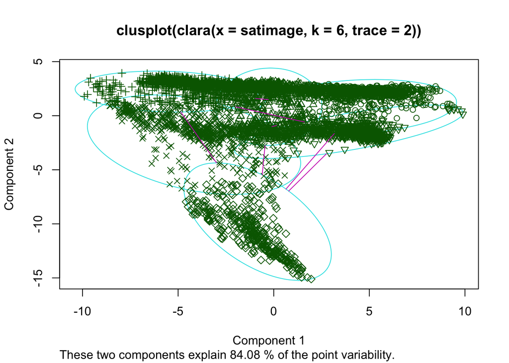

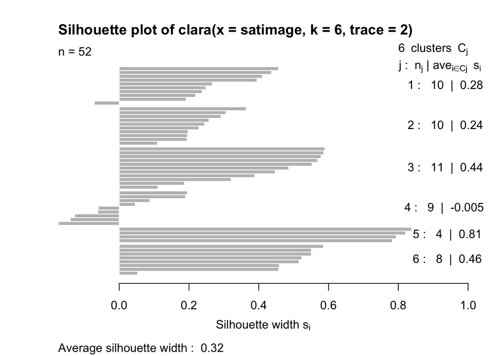

```r
#clusplot(clara1)
plot(clara1)
```

## Model-Based Clustering

- Assumes that the sample observations were generated by a mixture of distributions
- Often a mixture of mutlivariate normal distributions
- And each component of the mixture identifies/depicts a cluster

# Appendix

## LLM Finetuning

- PAM is computationally expensive
- K-means is sensitive to outliers

## Cluster of Vars

Sure! Here is a more detailed summary with additional context and explanations to help understand the methods and their applications, along with associated R code examples where required:

### Clustering Variables Using ClustOfVar

**What**: - ClustOfVar is an algorithm designed to cluster both quantitative and qualitative variables into cohesive groups.

**How**: - Introduces a synthetic variable for each cluster, which is the first principal component of the variables within that cluster. This synthetic variable guides the clustering process.

**Why**: - Clustering mixed data types (both quantitative and qualitative) can be challenging. ClustOfVar provides a way to handle this by summarizing the cluster with a synthetic variable, ensuring that both types of data contribute meaningfully to the clustering.

**R Code Example**:

```r
# Install and load ClustOfVar package
install.packages("ClustOfVar")
library(ClustOfVar)

# Example data frame with mixed types
data <- data.frame(
  num1 = rnorm(100),
  num2 = rnorm(100),
  cat1 = as.factor(sample(letters[1:3], 100, replace = TRUE))
)

# Clustering variables using ClustOfVar
tree <- hclustvar(X.quanti = data[, sapply(data, is.numeric)], X.quali = data[, sapply(data, is.factor)])
summary(tree)
plot(tree)
```

### Synthetic Variables and Homogeneity

**What**: - Synthetic variables are created to measure the homogeneity of a cluster, defined as the sum of $R^2$ values between the synthetic variable and each variable in the cluster.

**How**: - For each cluster, compute the synthetic variable and the $R^2$ values between this synthetic variable and each member variable. The sum of these $R^2$ values defines the homogeneity of the cluster.

**Why**: - This approach ensures that the variables within each cluster are closely related, promoting more meaningful and interpretable clusters.

### Hierarchical Clustering Algorithm

**What**: - An agglomerative hierarchical clustering procedure that merges clusters based on a homogeneity measure.

**How**: - The algorithm merges two clusters $A$ and $B$ such that the decrease in homogeneity $d(A, B) = H(A) + H(B) - H(A \cup B)$ is minimized.

**Why**: - Hierarchical clustering builds a tree of clusters (dendrogram) which helps in visualizing the clustering process and determining the optimal number of clusters.

**R Code Example**:

```r
# Perform hierarchical clustering on synthetic variables
d <- dist(data)
hc <- hclust(d, method = "complete")
plot(hc)
```

### Partitioning Algorithm

**What**: - A non-hierarchical clustering method that uses synthetic variables to guide clustering.

**How**: - Measures the association between actual variables and synthetic variables using the canonical correlation coefficient, allocating variables to clusters to minimize dissimilarity (maximize canonical correlation).

**Why**: - This method is useful when the number of clusters is pre-specified or needs to be determined a priori, allowing for flexible and efficient clustering.

### Choosing the Number of Clusters

**What**: - Cluster stability is assessed using resampling techniques like bootstrapping.

**How**: - Generate bootstrap samples, apply the clustering algorithm to each sample, and use the Rand index to compare the bootstrap clusters to the original clusters.

**Why**: - This approach helps in determining the robustness of the clusters and selecting the optimal number of clusters.

**R Code Example for Assessing Cluster Stability**:

```r
# Bootstrap resampling to assess cluster stability
set.seed(123)
boot_hc <- boot(hclustvar, R = 100, sim = "ordinary", stype = "i", data = data)
boot_hc
```

### Biclustering

**What**: - Identifies subgroups of observations and variables that are highly correlated, useful in contexts such as gene expression data.

**How**: - Simultaneously clusters rows and columns of a data matrix to find patterns specific to subsets of samples and variables.

**Why**: - Traditional clustering methods may miss these specific patterns. Biclustering helps in identifying co-expressed genes in subsets of samples, which is crucial in biological studies.

**R Code Example for Biclustering**:

```r
# Install and load biclust package
install.packages("biclust")
library(biclust)

# Example biclustering
data <- matrix(rnorm(1000), nrow = 100, ncol = 10)
result <- biclust(data, method = BCCC())
summary(result)
plot(result)
```

### Practical Considerations

**Selection of Clustering Algorithms**: - **Theoretical Considerations**: - Computational complexity affects run time and memory usage. - Assumptions about data (e.g., normality) and pre-specification of the number of clusters. - **Empirical Considerations**: - Performance on real-world datasets, including stability, correspondence with manual labels, and the ability to identify predictive variables.

### Labelling Cells in Flow Cytometry

**Context**: - Modern experimental techniques measure multiple variables on millions of cells rapidly. Clustering algorithms are essential for efficiently labelling cells (e.g., T cells, B cells).

**Manual vs. Automated Clustering**: - Manual clustering is slow but trusted. Automated algorithms need to reproduce manual clusterings accurately and identify biologically relevant clusters.

**Assessment of ClustOfVar**: - Performance can be slow with many variables. - A parallel version was planned but not implemented. - The package is on CRAN but has not been updated in years. - The algorithm helps guide the number of clusters selected, but per-cluster stability assessments are lacking.

### Key References

- **Aghaeepour et al. (2013)**: Assessed automated flow cytometry data analysis techniques.
- **Chavent et al. (2012)**: Discussed orthogonal rotation in PCAMIX.
- **Hennig (2007)**: Discussed cluster-wise assessment of cluster stability.
- **Hubert and Arabie (1985)**: Proposed the Adjusted Rand Index.
- **Rand (1971)**: Introduced the Rand Index for evaluating clustering methods.

### Additional Context

- **Gene Expression Data**: Biclustering is particularly useful in gene expression studies where specific genes are co-expressed in certain conditions.
- **Clustering Mixed Data**: ClustOfVar and similar methods are essential for clustering mixed data types, which are common in real-world datasets.

This detailed summary provides a comprehensive overview of the document’s content, including additional context and practical examples of how these methods can be implemented in R.